# CS 422 - Homework 6

Imaduddin Sheikh

###### Due Date: Wednesday, Mar 30 2022 11:59:59 PM Chicago Time [Extension Requested]

### 2. Practicum Problems

### 2.1. Association Rules

```r
setwd("~/Homework 6")
library(arules)
```

### Part 2.1(a)

```r
products.df <- read.csv("products.csv", header = FALSE)
```

```r
# tr1.df <- read.transactions("tr-1k.csv", format = 'basket', cols = c(1), header = FALSE, sep = ',')
# write(tr1.df, "tr-1k-canonical.csv")
# tr1.trans <- read.csv("tr-1k-canonical.csv", header = FALSE, col.names = c("items"))
# tr1.canonical.df <- (apply(tr1.trans, 1, replacement.function))
# write(tr1.canonical.df, "tr-1k-canonical.csv")
```

```r
# tr5.df <- read.transactions("tr-5k.csv", format = 'basket', cols = c(1), header = FALSE, sep = ',')
# write(tr5.df, "tr-5k-canonical.csv")
# tr5.trans <- read.csv("tr-5k-canonical.csv", header = FALSE, col.names = c("items"))
# tr5.canonical.df <- (apply(tr5.trans, 1, replacement.function))
# write(tr5.canonical.df, "tr-5k-canonical.csv")
```

```r
# tr20.df <- read.transactions("tr-20k.csv", format = 'basket', cols = c(1), header = FALSE, sep = ',')
# write(tr20.df, "tr-20k-canonical.csv")
# tr20.trans <- read.csv("tr-20k-canonical.csv", header = FALSE, col.names = c("items"))
# tr20.canonical.df <- (apply(tr20.trans, 1, replacement.function))
# write(tr20.canonical.df, "tr-20k-canonical.csv")
```

```r
# tr75.df <- read.transactions("tr-75k.csv", format = 'basket', cols = c(1), header = FALSE, sep = ',')
# write(tr75.df, "tr-75k-canonical.csv")
# tr75.trans <- read.csv("tr-75k-canonical.csv", header = FALSE, col.names = c("items"))
# tr75.canonical.df <- (apply(tr75.trans, 1, replacement.function))
# write(tr75.canonical.df, "tr-75k-canonical.csv")
```

### Part 2.1(b)

```r
tr1k.df <- read.transactions("tr-1k-canonical.csv",format = 'basket', header = FALSE, sep = ',')
tr5k.df <- read.transactions("tr-5k-canonical.csv",format = 'basket', header = FALSE, sep = ',')
tr20k.df <- read.transactions("tr-20k-canonical.csv",format = 'basket', header = FALSE, sep = ',')
tr75k.df <- read.transactions("tr-75k-canonical.csv",format = 'basket', header = FALSE, sep = ',')
```

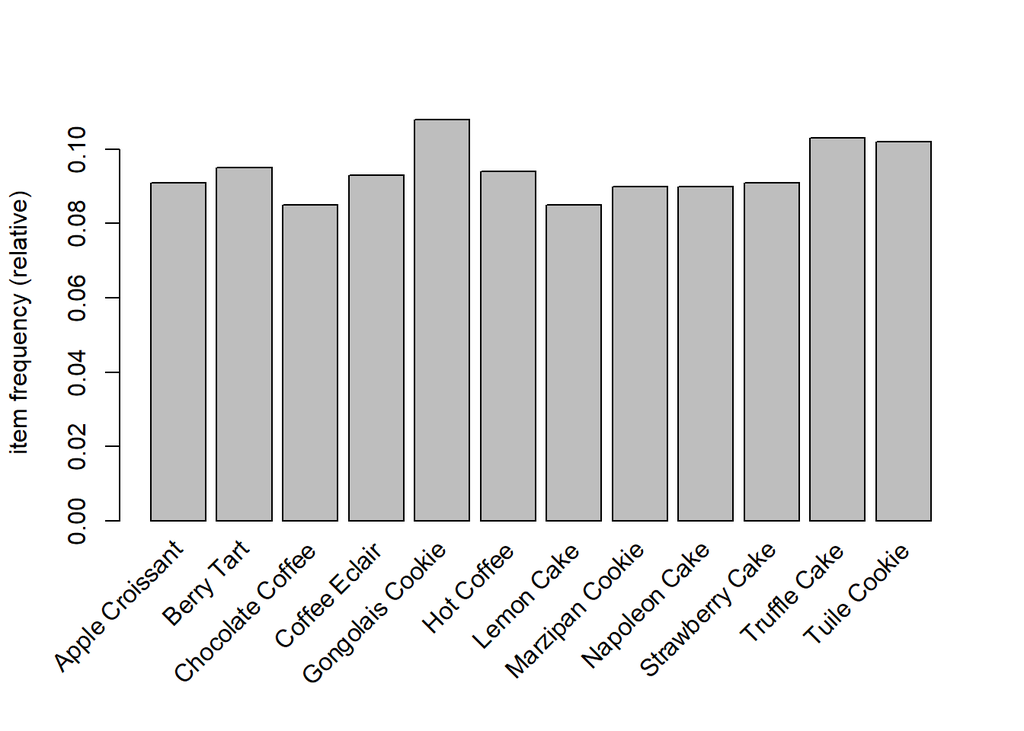

```r
itemFrequencyPlot(tr1k.df, support = 0.085)
```

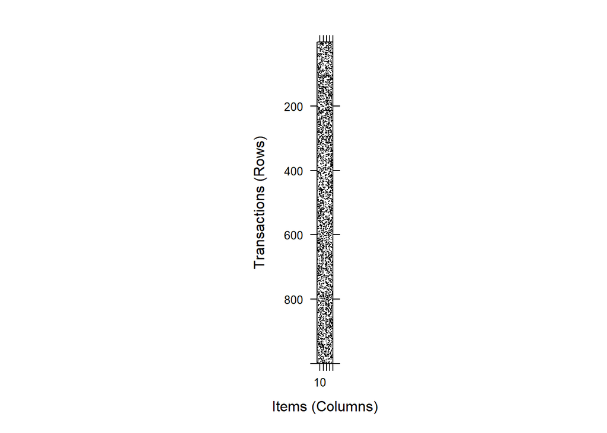

```r
image(tr1k.df)
```

```r
rules.1k <- apriori(tr1k.df, parameter=list(support=0.05, target="frequent itemsets"))
```

```
## Apriori
##
## Parameter specification:
##  confidence minval smax arem  aval originalSupport maxtime support minlen
##          NA    0.1    1 none FALSE            TRUE       5    0.05      1
##  maxlen            target  ext
##      10 frequent itemsets TRUE
##
## Algorithmic control:
##  filter tree heap memopt load sort verbose
##     0.1 TRUE TRUE  FALSE TRUE    2    TRUE
##
## Absolute minimum support count: 50
##
## set item appearances ...[0 item(s)] done [0.00s].
## set transactions ...[50 item(s), 1000 transaction(s)] done [0.00s].
## sorting and recoding items ... [40 item(s)] done [0.00s].
## creating transaction tree ... done [0.00s].
## checking subsets of size 1 2 done [0.00s].
## sorting transactions ... done [0.00s].
## writing ... [42 set(s)] done [0.00s].
## creating S4 object  ... done [0.00s].
```

```r
inspect(head(rules.1k, by="support", 15))
```

```
##      items              support count
## [1]  {Gongolais Cookie} 0.108   108
## [2]  {Truffle Cake}     0.103   103
## [3]  {Tuile Cookie}     0.102   102
## [4]  {Berry Tart}       0.095    95
## [5]  {Hot Coffee}       0.094    94
## [6]  {Coffee Eclair}    0.093    93
## [7]  {Strawberry Cake}  0.091    91
## [8]  {Apple Croissant}  0.091    91
## [9]  {Marzipan Cookie}  0.090    90
## [10] {Napoleon Cake}    0.090    90
## [11] {Lemon Cake}       0.085    85
## [12] {Chocolate Coffee} 0.085    85
## [13] {Chocolate Cake}   0.084    84
## [14] {Cherry Tart}      0.084    84
## [15] {Apple Danish}     0.084    84
```

```r
rules.1k <- apriori(tr1k.df, parameter=list(support=0.01, confidence = 0.95, target="rules"))
```

```
## Apriori
##
## Parameter specification:
##  confidence minval smax arem  aval originalSupport maxtime support minlen
##        0.95    0.1    1 none FALSE            TRUE       5    0.01      1
##  maxlen target  ext
##      10  rules TRUE
##
## Algorithmic control:
##  filter tree heap memopt load sort verbose
##     0.1 TRUE TRUE  FALSE TRUE    2    TRUE
##
## Absolute minimum support count: 10
##
## set item appearances ...[0 item(s)] done [0.00s].
## set transactions ...[50 item(s), 1000 transaction(s)] done [0.00s].
## sorting and recoding items ... [50 item(s)] done [0.00s].
## creating transaction tree ... done [0.00s].
## checking subsets of size 1 2 3 4 5 done [0.00s].
## writing ... [50 rule(s)] done [0.00s].
## creating S4 object  ... done [0.00s].
```

```r
inspect(head(rules.1k, by="lift", 15))
```

```
##      lhs                       rhs              support confidence coverage     lift count
## [1]  {Vanilla Frappuccino,
##       Walnut Cookie}        => {Chocolate Tart}   0.018  1.0000000    0.018 19.60784    18
## [2]  {Apple Pie,
##       Coffee Eclair,
##       Hot Coffee}           => {Almond Twist}     0.024  1.0000000    0.024 15.38462    24
## [3]  {Raspberry Cookie,
##       Raspberry Lemonade}   => {Lemon Cookie}     0.029  1.0000000    0.029 15.15152    29
## [4]  {Green Tea,
##       Lemon Lemonade,
##       Raspberry Lemonade}   => {Lemon Cookie}     0.019  1.0000000    0.019 15.15152    19
## [5]  {Green Tea,
##       Lemon Cookie,
##       Raspberry Lemonade}   => {Lemon Lemonade}   0.019  1.0000000    0.019 15.15152    19
## [6]  {Green Tea,
##       Lemon Lemonade,
##       Raspberry Cookie}     => {Lemon Cookie}     0.019  1.0000000    0.019 15.15152    19
## [7]  {Green Tea,
##       Lemon Cookie,
##       Raspberry Cookie}     => {Lemon Lemonade}   0.019  1.0000000    0.019 15.15152    19
## [8]  {Green Tea,
##       Raspberry Cookie,
##       Raspberry Lemonade}   => {Lemon Lemonade}   0.019  1.0000000    0.019 15.15152    19
## [9]  {Lemon Lemonade,
##       Raspberry Cookie,
##       Raspberry Lemonade}   => {Lemon Cookie}     0.028  1.0000000    0.028 15.15152    28
## [10] {Green Tea,
##       Raspberry Cookie,
##       Raspberry Lemonade}   => {Lemon Cookie}     0.019  1.0000000    0.019 15.15152    19
## [11] {Green Tea,
##       Lemon Lemonade,
##       Raspberry Cookie,
##       Raspberry Lemonade}   => {Lemon Cookie}     0.019  1.0000000    0.019 15.15152    19
## [12] {Green Tea,
##       Lemon Cookie,
##       Raspberry Cookie,
##       Raspberry Lemonade}   => {Lemon Lemonade}   0.019  1.0000000    0.019 15.15152    19
## [13] {Almond Twist,
##       Coffee Eclair,
##       Hot Coffee}           => {Apple Pie}        0.024  1.0000000    0.024 14.70588    24
## [14] {Lemon Lemonade,
##       Raspberry Lemonade}   => {Lemon Cookie}     0.028  0.9655172    0.029 14.62905    28
## [15] {Raspberry Cookie,
##       Raspberry Lemonade}   => {Lemon Lemonade}   0.028  0.9655172    0.029 14.62905    28
```

The association rules above provide a general picture of the 1000 transactions recorded. In this data set, some interesting rules can be found. One being that customers who bought Vanilla Frappuccino and Walnut Cookie were very likely to buy Chocolate Tart. A very high lift value and low support value supports this fact.

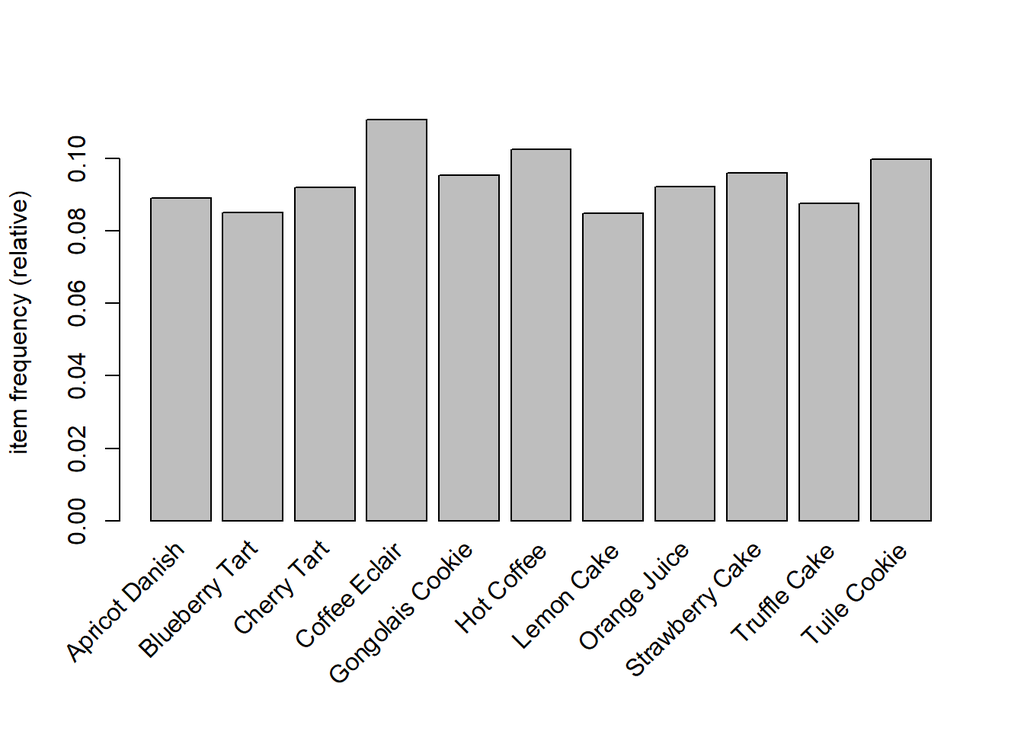

```r
itemFrequencyPlot(tr5k.df, support = 0.085)
```

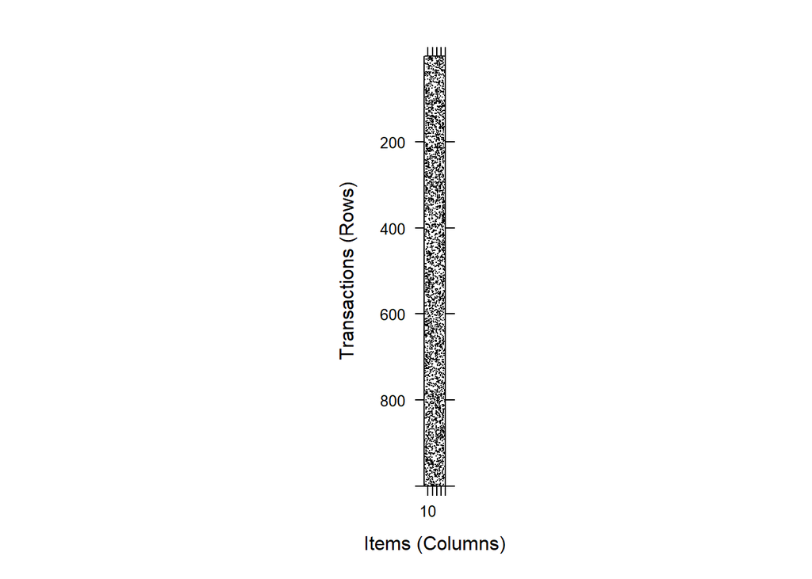

```r
image(tr1k.df)
```

```r
rules.5k <- apriori(tr5k.df, parameter=list(support=0.05, target="frequent itemsets"))
```

```
## Apriori
##
## Parameter specification:
##  confidence minval smax arem  aval originalSupport maxtime support minlen
##          NA    0.1    1 none FALSE            TRUE       5    0.05      1
##  maxlen            target  ext
##      10 frequent itemsets TRUE
##
## Algorithmic control:
##  filter tree heap memopt load sort verbose
##     0.1 TRUE TRUE  FALSE TRUE    2    TRUE
##
## Absolute minimum support count: 250
##
## set item appearances ...[0 item(s)] done [0.00s].
## set transactions ...[50 item(s), 5000 transaction(s)] done [0.00s].
## sorting and recoding items ... [38 item(s)] done [0.00s].
## creating transaction tree ... done [0.00s].
## checking subsets of size 1 2 done [0.00s].
## sorting transactions ... done [0.00s].
## writing ... [39 set(s)] done [0.00s].
## creating S4 object  ... done [0.00s].
```

```r
inspect(head(rules.5k, by="support", 15))
```

```
##      items               support count
## [1]  {Coffee Eclair}     0.1108  554
## [2]  {Hot Coffee}        0.1026  513
## [3]  {Tuile Cookie}      0.0998  499
## [4]  {Strawberry Cake}   0.0960  480
## [5]  {Gongolais Cookie}  0.0954  477
## [6]  {Orange Juice}      0.0922  461
## [7]  {Cherry Tart}       0.0920  460
## [8]  {Apricot Danish}    0.0892  446
## [9]  {Truffle Cake}      0.0876  438
## [10] {Blueberry Tart}    0.0852  426
## [11] {Lemon Cake}        0.0850  425
## [12] {Marzipan Cookie}   0.0836  418
## [13] {Opera Cake}        0.0836  418
## [14] {Apricot Croissant} 0.0822  411
## [15] {Napoleon Cake}     0.0818  409
```

Coffee Eclair, Hot Coffee and Tuile Cookie(also Strawberry Cake) have overtaken Gongolais Cookie in this data set which is evident by larger support values.

```r
rules.5k <- apriori(tr5k.df, parameter=list(support=0.01, confidence = 0.95, target="rules"))
```

```
## Apriori
##
## Parameter specification:
##  confidence minval smax arem  aval originalSupport maxtime support minlen
##        0.95    0.1    1 none FALSE            TRUE       5    0.01      1
##  maxlen target  ext
##      10  rules TRUE
##
## Algorithmic control:
##  filter tree heap memopt load sort verbose
##     0.1 TRUE TRUE  FALSE TRUE    2    TRUE
##
## Absolute minimum support count: 50
##
## set item appearances ...[0 item(s)] done [0.00s].
## set transactions ...[50 item(s), 5000 transaction(s)] done [0.00s].
## sorting and recoding items ... [50 item(s)] done [0.00s].
## creating transaction tree ... done [0.00s].
## checking subsets of size 1 2 3 4 5 done [0.00s].
## writing ... [28 rule(s)] done [0.00s].
## creating S4 object  ... done [0.00s].
```

```r
inspect(head(rules.5k, by="lift", 15))
```

```
##      lhs                     rhs                support confidence coverage     lift count
## [1]  {Green Tea,
##       Lemon Lemonade,
##       Raspberry Lemonade} => {Raspberry Cookie}  0.0212  1.0000000   0.0212 15.62500   106
## [2]  {Green Tea,
##       Lemon Cookie,
##       Raspberry Lemonade} => {Raspberry Cookie}  0.0212  1.0000000   0.0212 15.62500   106
## [3]  {Green Tea,
##       Lemon Cookie,
##       Lemon Lemonade,
##       Raspberry Lemonade} => {Raspberry Cookie}  0.0212  1.0000000   0.0212 15.62500   106
## [4]  {Green Tea,
##       Lemon Lemonade,
##       Raspberry Cookie}   => {Lemon Cookie}      0.0212  1.0000000   0.0212 15.57632   106
## [5]  {Green Tea,
##       Lemon Lemonade,
##       Raspberry Lemonade} => {Lemon Cookie}      0.0212  1.0000000   0.0212 15.57632   106
## [6]  {Green Tea,
##       Raspberry Cookie,
##       Raspberry Lemonade} => {Lemon Cookie}      0.0212  1.0000000   0.0212 15.57632   106
## [7]  {Lemon Lemonade,
##       Raspberry Cookie,
##       Raspberry Lemonade} => {Lemon Cookie}      0.0262  1.0000000   0.0262 15.57632   131
## [8]  {Green Tea,
##       Lemon Lemonade,
##       Raspberry Cookie,
##       Raspberry Lemonade} => {Lemon Cookie}      0.0212  1.0000000   0.0212 15.57632   106
## [9]  {Lemon Cookie,
##       Lemon Lemonade,
##       Raspberry Lemonade} => {Raspberry Cookie}  0.0262  0.9924242   0.0264 15.50663   131
## [10] {Green Tea,
##       Lemon Cookie,
##       Lemon Lemonade}     => {Raspberry Cookie}  0.0212  0.9906542   0.0214 15.47897   106
## [11] {Green Tea,
##       Raspberry Cookie,
##       Raspberry Lemonade} => {Lemon Lemonade}    0.0212  1.0000000   0.0212 15.43210   106
## [12] {Green Tea,
##       Lemon Cookie,
##       Raspberry Lemonade} => {Lemon Lemonade}    0.0212  1.0000000   0.0212 15.43210   106
## [13] {Lemon Cookie,
##       Raspberry Cookie,
##       Raspberry Lemonade} => {Lemon Lemonade}    0.0262  1.0000000   0.0262 15.43210   131
## [14] {Green Tea,
##       Lemon Cookie,
##       Raspberry Cookie,
##       Raspberry Lemonade} => {Lemon Lemonade}    0.0212  1.0000000   0.0212 15.43210   106
## [15] {Green Tea,
##       Lemon Cookie,
##       Raspberry Cookie}   => {Lemon Lemonade}    0.0212  0.9906542   0.0214 15.28787   106
```

The association rules above show that Lemon lemonades and cookies go very highly and likely with raspberry cookies and lemonade, with the help of green teas.

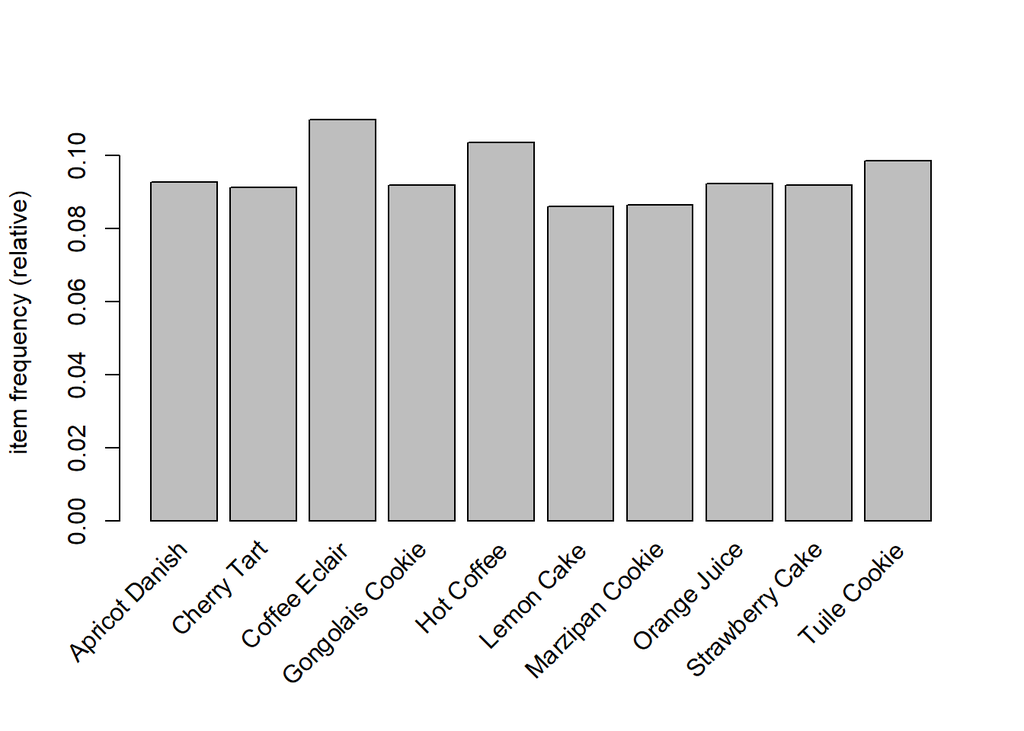

```r
itemFrequencyPlot(tr20k.df, support = 0.085)
```

[figure not shown]

```r
image(tr20k.df)
```

```r
rules.20k <- apriori(tr20k.df, parameter=list(support=0.05, target="frequent itemsets"))
```

```
## Apriori
##
## Parameter specification:
##  confidence minval smax arem  aval originalSupport maxtime support minlen
##          NA    0.1    1 none FALSE            TRUE       5    0.05      1
##  maxlen            target  ext
##      10 frequent itemsets TRUE
##
## Algorithmic control:
##  filter tree heap memopt load sort verbose
##     0.1 TRUE TRUE  FALSE TRUE    2    TRUE
##
## Absolute minimum support count: 1000
##
## set item appearances ...[0 item(s)] done [0.00s].
## set transactions ...[50 item(s), 20000 transaction(s)] done [0.01s].
## sorting and recoding items ... [38 item(s)] done [0.00s].
## creating transaction tree ... done [0.02s].
## checking subsets of size 1 2 done [0.00s].
## sorting transactions ... done [0.00s].
## writing ... [39 set(s)] done [0.00s].
## creating S4 object  ... done [0.01s].
```

```r
inspect(head(rules.20k, by="support", 15))
```

```
##      items              support count
## [1]  {Coffee Eclair}    0.10985 2197
## [2]  {Hot Coffee}       0.10360 2072
## [3]  {Tuile Cookie}     0.09865 1973
## [4]  {Apricot Danish}   0.09270 1854
## [5]  {Orange Juice}     0.09240 1848
## [6]  {Strawberry Cake}  0.09200 1840
## [7]  {Gongolais Cookie} 0.09185 1837
## [8]  {Cherry Tart}      0.09125 1825
## [9]  {Marzipan Cookie}  0.08645 1729
## [10] {Lemon Cake}       0.08600 1720
## [11] {Truffle Cake}     0.08465 1693
## [12] {Napoleon Cake}    0.08450 1690
## [13] {Berry Tart}       0.08430 1686
## [14] {Blueberry Tart}   0.08390 1678
## [15] {Chocolate Cake}   0.08365 1673
```

There is not a significant result in the 20,000-transaction data set when compared with the products frequently found/bought in transactions in the data set with 5,000 transactions. COffee Eclair, Hot Coffee and Tuile Cookie were top 3 back there as well.

```r
rules.20k <- apriori(tr20k.df, parameter=list(support=0.01, confidence = 0.95, target="rules"))
```

```
## Apriori
##
## Parameter specification:
##  confidence minval smax arem  aval originalSupport maxtime support minlen
##        0.95    0.1    1 none FALSE            TRUE       5    0.01      1
##  maxlen target  ext
##      10  rules TRUE
##
## Algorithmic control:
##  filter tree heap memopt load sort verbose
##     0.1 TRUE TRUE  FALSE TRUE    2    TRUE
##
## Absolute minimum support count: 200
##
## set item appearances ...[0 item(s)] done [0.00s].
## set transactions ...[50 item(s), 20000 transaction(s)] done [0.01s].
## sorting and recoding items ... [50 item(s)] done [0.01s].
## creating transaction tree ... done [0.01s].
## checking subsets of size 1 2 3 4 5 done [0.01s].
## writing ... [28 rule(s)] done [0.00s].
## creating S4 object  ... done [0.00s].
```

```r
inspect(head(rules.20k, by="lift", 15))
```

```
##      lhs                     rhs                  support confidence coverage     lift count
## [1]  {Green Tea,
##       Lemon Cookie,
##       Raspberry Cookie,
##       Raspberry Lemonade} => {Lemon Lemonade}     0.02040  1.0000000  0.02040 15.02630   408
## [2]  {Green Tea,
##       Raspberry Cookie,
##       Raspberry Lemonade} => {Lemon Lemonade}     0.02045  0.9975610  0.02050 14.98965   409
## [3]  {Green Tea,
##       Lemon Cookie,
##       Raspberry Lemonade} => {Lemon Lemonade}     0.02045  0.9951338  0.02055 14.95318   409
## [4]  {Lemon Cookie,
##       Raspberry Cookie,
##       Raspberry Lemonade} => {Lemon Lemonade}     0.02545  0.9941406  0.02560 14.93825   509
## [5]  {Green Tea,
##       Lemon Cookie,
##       Raspberry Cookie}   => {Lemon Lemonade}     0.02040  0.9927007  0.02055 14.91662   408
## [6]  {Apple Croissant,
##       Apple Tart,
##       Cherry Soda}        => {Apple Danish}       0.02100  0.9929078  0.02115 14.69886   420
## [7]  {Green Tea,
##       Lemon Lemonade,
##       Raspberry Cookie,
##       Raspberry Lemonade} => {Lemon Cookie}       0.02040  0.9975550  0.02045 14.61619   408
## [8]  {Green Tea,
##       Lemon Cookie,
##       Lemon Lemonade,
##       Raspberry Cookie}   => {Raspberry Lemonade} 0.02040  1.0000000  0.02040 14.60920   408
## [9]  {Green Tea,
##       Lemon Lemonade,
##       Raspberry Lemonade} => {Lemon Cookie}       0.02045  0.9951338  0.02055 14.58072   409
## [10] {Green Tea,
##       Raspberry Cookie,
##       Raspberry Lemonade} => {Lemon Cookie}       0.02040  0.9951220  0.02050 14.58054   408
## [11] {Lemon Cookie,
##       Lemon Lemonade,
##       Raspberry Cookie}   => {Raspberry Lemonade} 0.02545  0.9960861  0.02555 14.55202   509
## [12] {Green Tea,
##       Lemon Cookie,
##       Lemon Lemonade}     => {Raspberry Lemonade} 0.02045  0.9951338  0.02055 14.53811   409
## [13] {Lemon Lemonade,
##       Raspberry Cookie,
##       Raspberry Lemonade} => {Lemon Cookie}       0.02545  0.9922027  0.02565 14.53777   509
## [14] {Green Tea,
##       Lemon Cookie,
##       Raspberry Cookie}   => {Raspberry Lemonade} 0.02040  0.9927007  0.02055 14.50257   408
## [15] {Green Tea,
##       Lemon Lemonade,
##       Raspberry Cookie}   => {Lemon Cookie}       0.02040  0.9878935  0.02065 14.47463   408
```

Again, there is not much of a surprise in the association rules of this data set. Raspberry lemonades and cookies are going well in lemon cookies and lemonade, green tea is also involved. However, one interesting rule came up. Customers who bought croissant and tarts of apple flavor, and cherry soda at the same time also bought apple danish. Non-perishable apple-flavored products went well together.

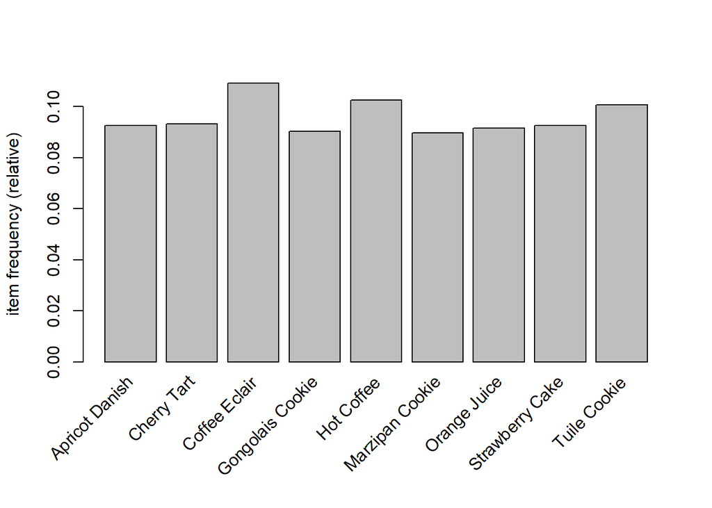

```r
itemFrequencyPlot(tr75k.df, support = 0.085)
```

[figure not shown]

```r
image(tr75k.df)
```

```r
rules.75k <- apriori(tr75k.df, parameter=list(support=0.05, target="frequent itemsets"))
```

```
## Apriori
##
## Parameter specification:
##  confidence minval smax arem  aval originalSupport maxtime support minlen
##          NA    0.1    1 none FALSE            TRUE       5    0.05      1
##  maxlen            target  ext
##      10 frequent itemsets TRUE
##
## Algorithmic control:
##  filter tree heap memopt load sort verbose
##     0.1 TRUE TRUE  FALSE TRUE    2    TRUE
##
## Absolute minimum support count: 3750
##
## set item appearances ...[0 item(s)] done [0.00s].
## set transactions ...[50 item(s), 75000 transaction(s)] done [0.03s].
## sorting and recoding items ... [38 item(s)] done [0.02s].
## creating transaction tree ... done [0.05s].
## checking subsets of size 1 2 done [0.00s].
## sorting transactions ... done [0.03s].
## writing ... [40 set(s)] done [0.00s].
## creating S4 object  ... done [0.00s].
```

```r
inspect(head(rules.75k, by="support", 15))
```

```
##      items               support    count
## [1]  {Coffee Eclair}     0.10924000 8193
## [2]  {Hot Coffee}        0.10266667 7700
## [3]  {Tuile Cookie}      0.10074667 7556
## [4]  {Cherry Tart}       0.09316000 6987
## [5]  {Strawberry Cake}   0.09264000 6948
## [6]  {Apricot Danish}    0.09257333 6943
## [7]  {Orange Juice}      0.09161333 6871
## [8]  {Gongolais Cookie}  0.09044000 6783
## [9]  {Marzipan Cookie}   0.08977333 6733
## [10] {Berry Tart}        0.08482667 6362
## [11] {Apricot Croissant} 0.08398667 6299
## [12] {Lemon Cake}        0.08361333 6271
## [13] {Chocolate Cake}    0.08353333 6265
## [14] {Chocolate Coffee}  0.08314667 6236
## [15] {Blueberry Tart}    0.08294667 6221
```

Same pattern of item set frequency as seen in the data sets with transactions of 5,000 and 20,000.

```r
rules.75k <- apriori(tr75k.df, parameter=list(support=0.01, confidence = 0.95, target="rules"))
```

```
## Apriori
##
## Parameter specification:
##  confidence minval smax arem  aval originalSupport maxtime support minlen
##        0.95    0.1    1 none FALSE            TRUE       5    0.01      1
##  maxlen target  ext
##      10  rules TRUE
##
## Algorithmic control:
##  filter tree heap memopt load sort verbose
##     0.1 TRUE TRUE  FALSE TRUE    2    TRUE
##
## Absolute minimum support count: 750
##
## set item appearances ...[0 item(s)] done [0.00s].
## set transactions ...[50 item(s), 75000 transaction(s)] done [0.03s].
## sorting and recoding items ... [50 item(s)] done [0.01s].
## creating transaction tree ... done [0.05s].
## checking subsets of size 1 2 3 4 5 done [0.02s].
## writing ... [27 rule(s)] done [0.00s].
## creating S4 object  ... done [0.01s].
```

```r
inspect(head(rules.75k, by="lift", 15))
```

```
##      lhs                     rhs                     support confidence   coverage     lift count
## [1]  {Green Tea,
##       Lemon Cookie,
##       Lemon Lemonade,
##       Raspberry Lemonade} => {Raspberry Cookie}   0.02073333  1.0000000 0.02073333 14.78415  1555
## [2]  {Green Tea,
##       Lemon Cookie,
##       Lemon Lemonade,
##       Raspberry Cookie}   => {Raspberry Lemonade} 0.02073333  1.0000000 0.02073333 14.76087  1555
## [3]  {Apple Danish,
##       Apple Tart,
##       Cherry Soda}        => {Apple Croissant}    0.02058667  0.9929260 0.02073333 14.75519  1544
## [4]  {Green Tea,
##       Lemon Lemonade,
##       Raspberry Lemonade} => {Raspberry Cookie}   0.02074667  0.9974359 0.02080000 14.74624  1556
## [5]  {Lemon Cookie,
##       Lemon Lemonade,
##       Raspberry Lemonade} => {Raspberry Cookie}   0.02556000  0.9973985 0.02562667 14.74569  1917
## [6]  {Green Tea,
##       Lemon Cookie,
##       Raspberry Cookie}   => {Raspberry Lemonade} 0.02073333  0.9980745 0.02077333 14.73245  1555
## [7]  {Green Tea,
##       Lemon Cookie,
##       Lemon Lemonade}     => {Raspberry Cookie}   0.02073333  0.9942455 0.02085333 14.69908  1555
## [8]  {Green Tea,
##       Lemon Lemonade,
##       Raspberry Cookie,
##       Raspberry Lemonade} => {Lemon Cookie}       0.02073333  0.9993573 0.02074667 14.69355  1555
## [9]  {Green Tea,
##       Lemon Lemonade,
##       Raspberry Cookie}   => {Raspberry Lemonade} 0.02074667  0.9942492 0.02086667 14.67599  1556
## [10] {Green Tea,
##       Lemon Cookie,
##       Lemon Lemonade}     => {Raspberry Lemonade} 0.02073333  0.9942455 0.02085333 14.67593  1555
## [11] {Green Tea,
##       Lemon Lemonade,
##       Raspberry Lemonade} => {Lemon Cookie}       0.02073333  0.9967949 0.02080000 14.65587  1555
## [12] {Green Tea,
##       Lemon Cookie,
##       Raspberry Cookie,
##       Raspberry Lemonade} => {Lemon Lemonade}     0.02073333  1.0000000 0.02073333 14.65416  1555
## [13] {Lemon Cookie,
##       Lemon Lemonade,
##       Raspberry Cookie}   => {Raspberry Lemonade} 0.02556000  0.9922360 0.02576000 14.64627  1917
## [14] {Green Tea,
##       Lemon Cookie,
##       Raspberry Lemonade} => {Raspberry Cookie}   0.02073333  0.9904459 0.02093333 14.64290  1555
## [15] {Apple Croissant,
##       Apple Tart,
##       Cherry Soda}        => {Apple Danish}       0.02058667  0.9910141 0.02077333 14.63976  1544
```

Same association rules observed as in 20,000-transaction data set.

### Part 2.1(c)

In the 1000-transaction data set, the association rules formed from it weren’t that generalized as they were in the the latter data sets. In the 5000, 20000, and 75000-transaction data sets, we could observe with good lift value how customers tend to buy lemon and raspberry-flavored cookies and lemonade, with green tea. With the emergence of apple-flavored items, we can easily observe that the patterns/rules begin to seem robust/generalizable as more transactions are added in the equation.